# Farmers_Classification

```python
import os
import pandas as pd
import seaborn as sns
import numpy as np
import matplotlib.pyplot as plt
from sklearn.ensemble import RandomForestClassifier
from sklearn.linear_model import LogisticRegression
from sklearn.ensemble import AdaBoostClassifier, GradientBoostingClassifier, RandomForestClassifier
from sklearn.neighbors import KNeighborsClassifier
from sklearn.model_selection import train_test_split
from sklearn.metrics import roc_auc_score
from sklearn.model_selection import cross_val_score
from sklearn.metrics import confusion_matrix
from sklearn.metrics import classification_report
from sklearn import model_selection
from sklearn.model_selection import RandomizedSearchCV
from scipy.stats import randint
%matplotlib inline
```

## Introduction

We do not know much about this dataset, but we are going to apply to it a dta science process, that will go from analysing, cleaning, performing some explanatory data analysis. Then we will run some classification algorithms, then analyse the results.

### Implemention approach

Our implementation will follow the steps below:

#### Data preparation

Before building our classification, we need to be sure that the format of the data is in an appropriate format. We will find out whether we have a good quality of dataset or not.

#### Loading Data

```python
os.chdir("D:\data\DataScience\FarmersExercise")
```

```python
#Loading data

data=pd.read_csv('exercise_03_train.csv')
data_test = pd.read_csv('exercise_03_test.csv')
print('The train dataset dimensions:', data.shape)
print('The test dataset  dimensions:', data_test.shape)
```

```
The train dataset dimensions: (40000, 101)
The test dataset  dimensions: (10000, 100)
```

We see that the dataset has 40000 rows and 101 columns, while the test data set has 10000 rows and 100 columns

#### Attributes of the dataset

let's take a look at a sample of data.

```python
data.head()
```

|  | x0 | x1 | x2 | x3 | x4 | x5 | x6 | x7 | x8 | x9 | ... | x91 | x92 | x93 | x94 | x95 | x96 | x97 | x98 | x99 | y |
| --- | --- | --- | --- | --- | --- | --- | --- | --- | --- | --- | --- | --- | --- | --- | --- | --- | --- | --- | --- | --- | --- |
| 0 | 83.812330 | -0.122672 | 65.391785 | 6.323478 | -18.511031 | 2.122648 | 0.319472 | 7.650422 | 7.713315 | 2.789856 | ... | 5.482352 | 12.211997 | asia | -3.201565 | -9.837196 | -21.092011 | 4.671140 | 0.588994 | -11.417083 | 0 |
| 1 | -0.445312 | -0.436077 | 12.981759 | 30.716674 | -34.981679 | -16.712862 | 0.530105 | 8.740222 | 56.044533 | 0.075118 | ... | -6.083035 | -5.098374 | asia | 5.433036 | 91.724841 | 4.305371 | 4.329130 | 0.371513 | 8.474528 | 0 |
| 2 | 82.927148 | 0.075277 | -29.096012 | -20.176841 | 10.109713 | -45.994005 | 0.618132 | 7.757838 | -69.749060 | -1.561335 | ... | 0.200787 | -7.174907 | asia | 2.595005 | -14.630603 | -3.743052 | -14.820376 | -2.366675 | 2.613091 | 0 |
| 3 | 370.736586 | -0.263338 | -75.273905 | -21.765844 | -72.478339 | -8.701108 | 0.332586 | 2.769763 | -35.815423 | 5.230400 | ... | 4.986738 | -6.649765 | asia | 4.349013 | -53.825281 | -12.243755 | -4.257462 | -0.352829 | -9.641206 | 0 |
| 4 | 33.775263 | -0.270047 | -40.486723 | 3.990431 | -13.733621 | -6.185321 | -0.733206 | -3.325673 | -5.055036 | -4.331587 | ... | 3.793349 | -0.865512 | asia | 4.432424 | 8.605707 | -23.823016 | -11.913495 | -0.139055 | -0.318227 | 0 |

5 rows × 101 columns

### Exploratory data analysis (EDA)

In this section, we need to check the statistical properties of the dataset and perform some preprocessing steps:

- Listing statistical properties
- Finding the missing values
- Replacing missing values
- Correlation
- Detecting Outliers

These analysis will be perform on both the training set and the test set.

```python
#Describing all the statistical properties of the training data
data[data.columns].describe()
```

|  | x0 | x1 | x2 | x3 | x4 | x5 | x6 | x7 | x8 | x9 | ... | x90 | x91 | x92 | x94 | x95 | x96 | x97 | x98 | x99 | y |
| --- | --- | --- | --- | --- | --- | --- | --- | --- | --- | --- | --- | --- | --- | --- | --- | --- | --- | --- | --- | --- | --- |
| count | 39989.000000 | 39990.000000 | 39994.000000 | 39990.000000 | 39993.000000 | 39991.000000 | 39993.000000 | 39991.000000 | 39993.000000 | 39992.000000 | ... | 39993.000000 | 39998.000000 | 39993.000000 | 39991.000000 | 39994.000000 | 39987.000000 | 39988.000000 | 39993.000000 | 39989.000000 | 40000.000000 |
| mean | 23.170164 | -0.058983 | 1.639221 | -0.815620 | 0.330524 | -0.849090 | -0.001158 | -0.035723 | -7.858543 | -0.057514 | ... | -14.261568 | 0.004626 | -0.014280 | -0.055800 | -0.016031 | -0.505100 | -1.065555 | 0.004239 | 0.301483 | 0.202200 |
| std | 108.214096 | 0.276964 | 36.483433 | 16.661057 | 41.008110 | 21.212786 | 0.740514 | 6.636854 | 35.469358 | 6.267267 | ... | 152.968028 | 4.998175 | 6.462462 | 5.631501 | 32.430072 | 13.254744 | 7.673260 | 1.020904 | 8.557658 | 0.401646 |
| min | -413.886484 | -1.170678 | -155.506382 | -72.148195 | -154.979397 | -85.536249 | -2.882761 | -25.258523 | -143.381931 | -24.544850 | ... | -668.827480 | -19.361109 | -28.136665 | -24.420972 | -147.149165 | -60.310880 | -30.759058 | -4.264671 | -35.844332 | 0.000000 |
| 25% | -50.139407 | -0.245316 | -22.916523 | -12.109172 | -27.373310 | -15.222230 | -0.503045 | -4.517139 | -31.579913 | -4.275924 | ... | -115.544278 | -3.378848 | -4.379327 | -3.884379 | -21.731951 | -9.355605 | -6.233989 | -0.684356 | -5.494577 | 0.000000 |
| 50% | 23.453277 | -0.061399 | 1.858545 | -0.779787 | 0.229034 | -0.771985 | 0.000274 | -0.003552 | -7.896462 | -0.092443 | ... | -10.979229 | -0.021378 | -0.040423 | -0.041302 | 0.226049 | -0.414283 | -1.037991 | 0.004070 | 0.268903 | 0.000000 |
| 75% | 95.426367 | 0.124552 | 26.245522 | 10.464449 | 27.898696 | 13.542902 | 0.491880 | 4.435969 | 15.757580 | 4.157671 | ... | 89.474205 | 3.367721 | 4.363682 | 3.762085 | 22.054702 | 8.438839 | 4.085890 | 0.692146 | 6.097647 | 0.000000 |
| max | 499.670953 | 1.094158 | 146.662970 | 65.122126 | 174.290057 | 81.773483 | 3.704431 | 32.662041 | 180.625693 | 24.063544 | ... | 599.273329 | 22.648086 | 27.252550 | 23.787097 | 134.227175 | 54.964038 | 32.236033 | 4.114639 | 36.351247 | 1.000000 |

8 rows × 95 columns

```python
dtypedict = {col:type(data[col][0]) for col in data.columns }
dtypedictstring=[col for col in dtypedict if dtypedict[col]==str]

display('These are the non numeric attributes: ',dtypedictstring)
```

```
'These are the non numeric attributes: '
```

```
['x34', 'x35', 'x41', 'x45', 'x68', 'x93']
```

- X34,x35,x68,x93 represent vehicle,days of the week, months , and continents. We will come back to these columns.
- x41 has parentheses that probably representing a negative number. We with convert them to numeric. The percent sign should be remove from x45.

```python
#Converting column x41 to numeric in training data
data['x41']=data['x41'].str.replace('$','')
data['x41']=data['x41'].str.replace(')','')
data['x41']=data['x41'].str.replace('(','-')
data['x41']=data['x41'].str.replace(',','')

data['x41'] = data['x41'].astype(float)

#Converting column x41 to numeric in test data
data_test['x41']=data_test['x41'].str.replace('$','')
data_test['x41']=data_test['x41'].str.replace(')','')
data_test['x41']=data_test['x41'].str.replace('(','-')
data_test['x41']=data_test['x41'].str.replace(',','')

data_test['x41'] = data_test['x41'].astype(float)
```

```python
#Converting x45 to numeric in training data
data['x45'] = data['x45'].str.replace("%",'')
data['x45'] = data['x45'].astype(float)


#Converting x45 to numeric in test data
data_test['x45'] = data_test['x45'].str.replace("%",'')
data_test['x45'] = data_test['x45'].astype(float)
```

Let's check the kind of distribution that we have in our dataset. our target variable is y. To better understand the overall distribution in the dataset, we will plot it as below.

```python
total = len(data['y'])
percentage_labels = (data['y'].value_counts()/total)
percentage_labels
```

```
0    0.7978
1    0.2022
Name: y, dtype: float64
```

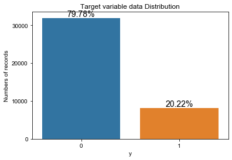

```python
sns.countplot(data.y).set_title('Target variable data Distribution')
ax= plt.gca()
for p in ax.patches:
    height = p.get_height()
    ax.text(p.get_x()+p.get_width()/2.,height+2,'{:.2f}%'.format(100*(height/total)),
           fontsize=14, ha='center',va='bottom')
sns.set(font_scale=1.5)
ax.set_xlabel=("Labels for target(y)")
ax.set_ylabel("Numbers of records");
```

As we can see about 80% of the data is classified as 0 and only about 20% as 1. Therefore, this dataset is somewhat imbalanced.

#### Finding missing values

```
The maximum count of null value in a column is 15 and the minimum is 15
```

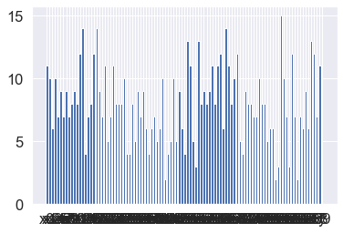

```python
nullvalues = data.isnull().sum()
nulldict = { col: nullvalues[col] for col in data.columns}
maxnull = max(nulldict.values())
minnull = max(nulldict.values())
print ("The maximum count of null value in a column is {} and the minimum is {}".format(maxnull,minnull))
plt.bar(*zip(*nulldict.items()));
```

As we can see, the highest number of null values in a column is 15. There are relatively few columns that have more than 10 null values. There are many methods for data amputation. Considering the number of missing values, we consider three different ways:

- just drop them
- replace them with the mean of that particular attribue
- replace them with the median of that particular attribute.

For this first iterantion,we will replace all missing values with the mean. Depending of our accuracy, we could come back and try amputing with the median.

```python
data_clean = data.fillna((data.mean()))
data_test_clean = data_test.fillna((data_test.mean()))
data_clean.head()
```

|  | x0 | x1 | x2 | x3 | x4 | x5 | x6 | x7 | x8 | x9 | ... | x91 | x92 | x93 | x94 | x95 | x96 | x97 | x98 | x99 | y |
| --- | --- | --- | --- | --- | --- | --- | --- | --- | --- | --- | --- | --- | --- | --- | --- | --- | --- | --- | --- | --- | --- |
| 0 | 83.812330 | -0.122672 | 65.391785 | 6.323478 | -18.511031 | 2.122648 | 0.319472 | 7.650422 | 7.713315 | 2.789856 | ... | 5.482352 | 12.211997 | asia | -3.201565 | -9.837196 | -21.092011 | 4.671140 | 0.588994 | -11.417083 | 0 |
| 1 | -0.445312 | -0.436077 | 12.981759 | 30.716674 | -34.981679 | -16.712862 | 0.530105 | 8.740222 | 56.044533 | 0.075118 | ... | -6.083035 | -5.098374 | asia | 5.433036 | 91.724841 | 4.305371 | 4.329130 | 0.371513 | 8.474528 | 0 |
| 2 | 82.927148 | 0.075277 | -29.096012 | -20.176841 | 10.109713 | -45.994005 | 0.618132 | 7.757838 | -69.749060 | -1.561335 | ... | 0.200787 | -7.174907 | asia | 2.595005 | -14.630603 | -3.743052 | -14.820376 | -2.366675 | 2.613091 | 0 |
| 3 | 370.736586 | -0.263338 | -75.273905 | -21.765844 | -72.478339 | -8.701108 | 0.332586 | 2.769763 | -35.815423 | 5.230400 | ... | 4.986738 | -6.649765 | asia | 4.349013 | -53.825281 | -12.243755 | -4.257462 | -0.352829 | -9.641206 | 0 |
| 4 | 33.775263 | -0.270047 | -40.486723 | 3.990431 | -13.733621 | -6.185321 | -0.733206 | -3.325673 | -5.055036 | -4.331587 | ... | 3.793349 | -0.865512 | asia | 4.432424 | 8.605707 | -23.823016 | -11.913495 | -0.139055 | -0.318227 | 0 |

5 rows × 101 columns

```python
data_clean.shape
```

```
(40000, 101)
```

### Dummy Variable Creation

Earlier data exploration, we saw these columns ['x34', 'x35', 'x68', 'x93'] were not numeric. We will create a one hot encoding on them and remove the original values.

```python
data_clean[['x34', 'x35', 'x68', 'x93']].head()
```

|  | x34 | x35 | x68 | x93 |
| --- | --- | --- | --- | --- |
| 0 | Honda | wed | July | asia |
| 1 | Honda | wednesday | Jun | asia |
| 2 | volkswagon | thurday | Aug | asia |
| 3 | volkswagon | thurday | July | asia |
| 4 | ford | thurday | July | asia |

```python
# Creating dummies vriables for training set
dumx34 = pd.get_dummies(data_clean['x34'],prefix='x34', drop_first=True)
data_clean=pd.concat([data_clean,dumx34],axis=1)

dumx35 = pd.get_dummies(data_clean['x35'],prefix='x35', drop_first=True)
data_clean=pd.concat([data_clean,dumx35],axis=1)

dumx68 = pd.get_dummies(data_clean['x68'],prefix='x68', drop_first=True)
data_clean=pd.concat([data_clean,dumx68],axis=1)

dumx93 = pd.get_dummies(data_clean['x93'],prefix='x93', drop_first=True)
data_clean=pd.concat([data_clean,dumx93],axis=1)


# Creating dummies vriables for test set
dumx34t = pd.get_dummies(data_test_clean['x34'],prefix='x34', drop_first=True)
data_test_clean=pd.concat([data_test_clean,dumx34t],axis=1)

dumx35 = pd.get_dummies(data_test_clean['x35'],prefix='x35', drop_first=True)
data_test_clean=pd.concat([data_test_clean,dumx35],axis=1)

dumx68 = pd.get_dummies(data_test_clean['x68'],prefix='x68', drop_first=True)
data_test_clean=pd.concat([data_test_clean,dumx68],axis=1)

dumx93 = pd.get_dummies(data_test_clean['x93'],prefix='x93', drop_first=True)
data_test_clean=pd.concat([data_test_clean,dumx93],axis=1)
```

#### Dropping the repeated variables

```python
data_clean=data_clean.drop(['x34', 'x35', 'x68', 'x93'],1)
data_test_clean=data_test_clean.drop(['x34', 'x35', 'x68', 'x93'],1)
print('After adding all the dummies variables, our data set currently has {} rows and {} columns in the training set.'.format(data_clean.shape[0],data_clean.shape[1]))
print('After adding all the dummies variables, our data set currently has {} rows and {} columns in the test set.'.format(data_test_clean.shape[0],data_test_clean.shape[1]))
```

```
After adding all the dummies variables, our data set currently has 40000 rows and 126 columns in the training set.
After adding all the dummies variables, our data set currently has 10000 rows and 125 columns in the test set.
```

### Checking for Outliers

The presence of outliers can drastically affect the quality of our model. Therefore, we will take a look at different percentiles.

```python
numcol = data.columns[:-2]
num_data = data_clean.loc[:,numcol]
num_data=num_data.drop(['x34', 'x35', 'x68', 'x93'],1)
;
```

```
''
```

```python
num_data.describe(percentiles=[.25,.5,.75,.90,.95,.99])
```

|  | x0 | x1 | x2 | x3 | x4 | x5 | x6 | x7 | x8 | x9 | ... | x88 | x89 | x90 | x91 | x92 | x94 | x95 | x96 | x97 | x98 |
| --- | --- | --- | --- | --- | --- | --- | --- | --- | --- | --- | --- | --- | --- | --- | --- | --- | --- | --- | --- | --- | --- |
| count | 40000.000000 | 40000.000000 | 40000.000000 | 40000.000000 | 40000.000000 | 40000.000000 | 40000.000000 | 40000.000000 | 40000.000000 | 40000.000000 | ... | 40000.000000 | 40000.000000 | 40000.000000 | 40000.000000 | 40000.000000 | 40000.000000 | 40000.000000 | 40000.000000 | 40000.000000 | 40000.000000 |
| mean | 23.170164 | -0.058983 | 1.639221 | -0.815620 | 0.330524 | -0.849090 | -0.001158 | -0.035723 | -7.858543 | -0.057514 | ... | -0.006529 | 0.015639 | -14.261568 | 0.004626 | -0.014280 | -0.055800 | -0.016031 | -0.505100 | -1.065555 | 0.004239 |
| std | 108.199215 | 0.276929 | 36.480696 | 16.658975 | 41.004521 | 21.210400 | 0.740449 | 6.636108 | 35.466255 | 6.266640 | ... | 9.831381 | 9.869596 | 152.954642 | 4.998050 | 6.461896 | 5.630867 | 32.427640 | 13.252589 | 7.672109 | 1.020814 |
| min | -413.886484 | -1.170678 | -155.506382 | -72.148195 | -154.979397 | -85.536249 | -2.882761 | -25.258523 | -143.381931 | -24.544850 | ... | -41.858393 | -38.104130 | -668.827480 | -19.361109 | -28.136665 | -24.420972 | -147.149165 | -60.310880 | -30.759058 | -4.264671 |
| 25% | -50.125517 | -0.245253 | -22.913420 | -12.103400 | -27.363543 | -15.217164 | -0.502930 | -4.515388 | -31.577232 | -4.275758 | ... | -6.629332 | -6.644403 | -115.523905 | -3.378397 | -4.378652 | -3.883104 | -21.727520 | -9.354915 | -6.232706 | -0.684156 |
| 50% | 23.424930 | -0.061324 | 1.847817 | -0.781818 | 0.234149 | -0.782450 | 0.000165 | -0.005902 | -7.888478 | -0.091566 | ... | -0.059227 | -0.054999 | -10.993847 | -0.020619 | -0.039918 | -0.042172 | 0.218706 | -0.419964 | -1.039537 | 0.004239 |
| 75% | 95.377307 | 0.124508 | 26.243775 | 10.460558 | 27.892034 | 13.539049 | 0.491688 | 4.433759 | 15.752120 | 4.157034 | ... | 6.611650 | 6.641672 | 89.425832 | 3.367497 | 4.362585 | 3.761151 | 22.053502 | 8.435538 | 4.084792 | 0.692049 |
| 90% | 161.749217 | 0.297362 | 48.481537 | 20.490956 | 52.843280 | 26.419838 | 0.950841 | 8.451865 | 37.541469 | 8.007084 | ... | 12.631711 | 12.722847 | 179.887112 | 6.418401 | 8.279210 | 7.105249 | 41.270476 | 16.345470 | 8.662591 | 1.323712 |
| 95% | 202.301350 | 0.400674 | 61.231449 | 26.560862 | 68.269601 | 34.075337 | 1.217641 | 10.863540 | 50.176374 | 10.302226 | ... | 16.116359 | 16.303750 | 232.409583 | 8.294971 | 10.600122 | 9.129766 | 52.878358 | 21.113483 | 11.582511 | 1.683928 |
| 99% | 276.123987 | 0.596563 | 86.327218 | 37.841394 | 96.581980 | 48.378108 | 1.730230 | 15.219690 | 75.087087 | 14.637474 | ... | 22.999366 | 23.127093 | 329.902868 | 11.673694 | 14.867671 | 13.003425 | 73.986294 | 30.213185 | 16.982405 | 2.364886 |
| max | 499.670953 | 1.094158 | 146.662970 | 65.122126 | 174.290057 | 81.773483 | 3.704431 | 32.662041 | 180.625693 | 24.063544 | ... | 40.869883 | 40.489708 | 599.273329 | 22.648086 | 27.252550 | 23.787097 | 134.227175 | 54.964038 | 32.236033 | 4.114639 |

11 rows × 95 columns

By looking at the table above, some data seems to be outliers, but without better information about the data set, we will just leave them alone.

#### Feature transformation

We will not remove the outliers, but we will transform the data to scale all continues features.

```python
#Normalizing training data
cols = list(num_data.columns)
df = data_clean[cols]
normalized_df =(df-df.mean())/df.std()
data_clean = data_clean.drop(cols, axis=1)
data_clean = pd.concat([data_clean,normalized_df], axis=1)
```

```python
#normalizing  test data
df = data_test_clean[cols]
normalizedt_df =(df-df.mean())/df.std()
data_test_clean = data_test_clean.drop(cols, axis=1)
data_test_clean = pd.concat([data_test_clean,normalizedt_df], axis=1)
```

### Selecting machine learning algorithms

We will try different ML algorithms in order to get an idea about the one that performs better on our data set.

We will split the training data to training set and validation set. We will apply different transformation to the test set provided, but it will be kept only to generate the final prediction.

```python
X = data_clean.drop('y', axis =1)
y = data_clean.y
X_train,X_test, y_train,y_test = train_test_split(X,y,test_size=0.25)
```

As you can see above, we have first removed the target variable from the original data set and assigned to a different variable. Then we have split the original data in training set and validation set. 25% of data has been kept for validation and 75% will be used for training.

#### 1 - K-Nearest Neighbor (KNN)

This ML algorithm tends to generate prediction that follow the tendency as that of its neigbor. K is the number of neigbors that is considered.

```python
knn = KNeighborsClassifier(n_neighbors=5,weights='uniform', algorithm='auto',leaf_size=30,p=2,metric='minkowski',metric_params=None)
```

Here we build a KNN classifier based on 5 neigbors. the weight is uniform meaning all neigbors will be weighted equally. the leaf_size just affect the speed of the construction of the model. p=2 indicates the power of Minkowski, which uses the euclidean distance on this case.

#### 2- Logistic regression

Logistic regresion generates the probability for the target variable using sigmod and other non linear functions in order to predict the target labels.

```python
glmMod = LogisticRegression(penalty='l1',dual = False,tol=0.0001,C=1.0,fit_intercept=True,intercept_scaling=1,class_weight=None,
                           random_state=None,solver='liblinear',max_iter=100,multi_class='ovr',verbose=2)
```

Here the penalty='l1' indicates the choice of the gradient descent algorithm. the tol indicates the tolerance of the stopping criteria. c=1 is the regularisation parameter. We choose max_iter=100 in order to iterate at most 100 time to allow our algorithm to converge.

#### 3- AdaBoost

AdaBoost is a boosting ensemble algorithm in which a strong algorithm is built using multiple weak classifiers. The algorithm makes the decision base on the number of iterations. In the first iteration, we start by taking random data points from the training dataset and building the model. After each iteration,the algorithm checks for data points in which the classifier does not perform well. Once those data points are identified by the algorithm based on error rate. in the next iteration, there are more chances that the algorithm will select the previously poorly classified data points and learn how to classify them. This process keeps running for the given number of iterations you provide.

```python
adaModel = AdaBoostClassifier(base_estimator=None,n_estimators=200,learning_rate=1.0)
```

#### 4- GradientBoosting

This is another ensemble machile learning algorithm that uses the basic regression algorithm to train the model. After training,we it calculates the error rate as well as the data points for which the algorithm did not perform well. In the next iteration, it considers the data points that did not perform well and retrain the model for better prediction. The agorithm uses the already generated model as well as a newly generated model to predict the values for the data points.

```python
gbMod = GradientBoostingClassifier(loss='deviance',learning_rate=0.1,n_estimators=200,subsample=1.0,min_samples_split=2,min_samples_leaf=1,
                                  min_weight_fraction_leaf=0.0,max_depth=3,init=None,random_state=None,max_features=None,verbose=0)
```

#### 5-RandomForest

This ML algorithm generates the number of decision trees and uses the voting mechanism to predict the target label.In this algorithm, there are a number of decision trees generated, creating a forest of trees, so it's called RandomForest.

```python
rfMod = RandomForestClassifier(n_estimators=10,criterion='gini',max_depth=None,min_samples_split=2,
                              min_samples_leaf=1,min_weight_fraction_leaf=0.0,max_features='auto',
                              max_leaf_nodes=None,bootstrap=True,oob_score=False,n_jobs=1, random_state=None,verbose=0)
```

#### Training Models Base model

```python
knn.fit(X_train,y_train)
glmMod.fit(X_train,y_train)
adaModel.fit(X_train,y_train)
gbMod.fit(X_train,y_train)
rfMod.fit(X_train,y_train)
```

```
[LibLinear]
```

```
RandomForestClassifier(bootstrap=True, class_weight=None, criterion='gini',
                       max_depth=None, max_features='auto', max_leaf_nodes=None,
                       min_impurity_decrease=0.0, min_impurity_split=None,
                       min_samples_leaf=1, min_samples_split=2,
                       min_weight_fraction_leaf=0.0, n_estimators=10, n_jobs=1,
                       oob_score=False, random_state=None, verbose=0,
                       warm_start=False)
```

#### The mean accuracy of the trained models

To Evaluate our model, we will consider two metrics: the accuracy score and the ROC-AUC score.

#### Testing the baseline model

After the training phase above, we will use the validation set to have an idea about how good or bad our training models perform. We have generated 5 classifiers as above.

```python
knnbase=knn.score(X_test,y_test)
```

```python
test_labels = knn.predict_proba(np.array(X_test.values))[:,1]
```

```python
knnbaseroc=roc_auc_score(y_test,test_labels,average='macro',sample_weight=None)
```

```python
glmbase=glmMod.score(X_test,y_test)
test_labels = glmMod.predict_proba(np.array(X_test.values))[:,1]
glmbaseroc=roc_auc_score(y_test,test_labels,average='macro',sample_weight=None)
```

```python
adabase = adaModel.score(X_test,y_test)
test_labels = adaModel.predict_proba(np.array(X_test.values))[:,1]
adarocbase = roc_auc_score(y_test,test_labels,average='macro',sample_weight=None)
```

```python
gBbase =gbMod.score(X_test,y_test)
test_labels = gbMod.predict_proba(np.array(X_test.values))[:,1]
gBbaseroc = roc_auc_score(y_test,test_labels,average='macro',sample_weight=None)
```

```python
rfbase =rfMod.score(X_test,y_test)
test_labels = rfMod.predict_proba(np.array(X_test.values))[:,1]
rfbaseroc = roc_auc_score(y_test,test_labels,average='macro',sample_weight=None)
```

```python
models =['KNN','GLMMod','adaBoost','gdBoost','rdForest']
Cols   =['BaseScore','BaseAUCROC','Score','AUCROC']
result=pd.DataFrame(index=models,columns=Cols)
```

```python
result.loc['KNN','BaseScore']=knnbase
result.loc['KNN','BaseAUCROC']=knnbaseroc
result.loc['GLMMod','BaseScore']=glmbase
result.loc['GLMMod','BaseAUCROC']=glmbaseroc
result.loc['adaBoost','BaseScore']=adabase
result.loc['adaBoost','BaseAUCROC']=adarocbase
result.loc['gdBoost','BaseScore']=gBbase
result.loc['gdBoost','BaseAUCROC']=gBbaseroc
result.loc['rdForest','BaseScore']=rfbase
result.loc['rdForest','BaseAUCROC']=rfbaseroc
result
```

|  | BaseScore | BaseAUCROC | Score | AUCROC |
| --- | --- | --- | --- | --- |
| KNN | 0.9194 | 0.948537 | NaN | NaN |
| GLMMod | 0.8898 | 0.901818 | NaN | NaN |
| adaBoost | 0.8776 | 0.899105 | NaN | NaN |
| gdBoost | 0.9272 | 0.96452 | NaN | NaN |
| rdForest | 0.861 | 0.898173 | NaN | NaN |

#### Feature engineering for the baseline model

Before proceding to the parameter tunning, we will select features that are important to our model. We will focus on the features that give us at least the baseline score above and consider them for our analysis. This will allow us to reduce noise and overfitting cause by the curse of dimensionality. For this purpose, we are going to train the model using the Random forest classifier, then we will have a general idea about the features important to us.

```python
X = data_clean.drop('y', axis =1)
y = data_clean.y
features = X.columns

forest = RandomForestClassifier(n_estimators=10000, random_state=0,n_jobs=-1)
forest.fit(X,y)
importances = forest.feature_importances_
indices = np.argsort(importances)[::-1]
for i in range(X.shape[1]):
    print('%2d) %-*s %f' %(i+1,30,features[i],importances[indices[i]]))
```

[output not shown]

After implementing this method, we have not seen a big improvement. Therefore, we will continue will all features.

### Optimizing the existing approach

We are going to try to improve our existing result by using some optimization approaches: cross-validation and hyperparameter tuning.

- Cross-validation Cross-validation is used avoid model overfitting, which is a technique that evaluates how well the classifier will perform on the data that it has not seen before. There are many other cross validation techniques, but we will use the k-fold CV, that trains the data k-1 times. At each iteration, some folds are used for training and some for testing.
- Hyperparameter tuning In the base model above, we basically used some default parameters. Hyperparameter tuning will consist of setting a range of parameters and select the one that perform better on our dataset.

#### Implementing Cross-validadion

We will implement the K-fold CV, with k=5. We will consider two scores to evaluate our models, the mean ROC-AUC and the mean standard deviation. Then can easily compare to our baseline approach. We will run this on our whole training set.

```python
def cross_validationGen(models, scr, X_train=X,y_train=y, cv=5,verbose=1):
    cvDict = {}
    for model in models:
        cvScore =cross_val_score(model,X_train,y_train,cv=cv, verbose=verbose,scoring=scr)
        cvDict[str(model).split('(')[0]] = [cvScore.mean(),cvScore.std()]
    return cvDict
```

```python
cvD = cross_validationGen(models=[knn,glmMod,adaModel,gbMod,rfMod], scr='roc_auc')
cvD
```

```
[Parallel(n_jobs=1)]: Using backend SequentialBackend with 1 concurrent workers.
[Parallel(n_jobs=1)]: Done   5 out of   5 | elapsed:  4.1min finished
[Parallel(n_jobs=1)]: Using backend SequentialBackend with 1 concurrent workers.
```

```
[LibLinear][LibLinear][LibLinear][LibLinear][LibLinear]
```

```
[Parallel(n_jobs=1)]: Done   5 out of   5 | elapsed:   47.8s finished
[Parallel(n_jobs=1)]: Using backend SequentialBackend with 1 concurrent workers.
[Parallel(n_jobs=1)]: Done   5 out of   5 | elapsed:  5.2min finished
[Parallel(n_jobs=1)]: Using backend SequentialBackend with 1 concurrent workers.
[Parallel(n_jobs=1)]: Done   5 out of   5 | elapsed:  3.8min finished
[Parallel(n_jobs=1)]: Using backend SequentialBackend with 1 concurrent workers.
[Parallel(n_jobs=1)]: Done   5 out of   5 | elapsed:   11.3s finished
```

```
{'KNeighborsClassifier': [0.9510719156807989, 0.0027447100316627384],
 'LogisticRegression': [0.9050051756291417, 0.0064729440831266544],
 'AdaBoostClassifier': [0.9031094259786174, 0.0033473247945824468],
 'GradientBoostingClassifier': [0.9672736959295596, 0.002429031671267343],
 'RandomForestClassifier': [0.9008190886914313, 0.003982294595295726]}
```

```python
result['cvROCAUC']='NaN'
result.loc['KNN','cvROCAUC']=cvD['KNeighborsClassifier'][0]
result.loc['GLMMod','cvROCAUC']=cvD['LogisticRegression'][0]
result.loc['adaBoost','cvROCAUC']=cvD['AdaBoostClassifier'][0]
result.loc['gdBoost','cvROCAUC']=cvD['GradientBoostingClassifier'][0]
result.loc['rdForest','cvROCAUC']=cvD['RandomForestClassifier'][0]
result
```

[output not shown]

The cross validation was performed on 5 different ML algorithms in order to check the one that works better for our data set. As we can see, Gradient Boosting and KNN seems to work better. Logistic regression seems to be very close to ada Boost, but we choose the latter because the standard deviation seems lower. Also, we see that the mean value and the std value we can conlude that our ROC-AUC score does not suffer from overfitting because the values does not deviate much from the baseline.

#### Implementing hyperparameter tuning

In order to select better parameters for our models, we will use a random search method. This method consist of randomly picking parameters from grid instead of trying all possibilites.

```python
knn = KNeighborsClassifier(n_neighbors=5,weights='uniform', algorithm='auto',leaf_size=30,p=2,metric='minkowski')
krange = [n for n in range(2,15)]
weights=['uniform', 'distance']
param_grid =dict(n_neighbors=krange,weights=weights)
gridsearchknn = RandomizedSearchCV(knn,param_grid,cv=5,scoring='roc_auc',n_iter=10, random_state=5).fit(X_train,y_train)
#rand =          RandomizedSearchCV(knn, param_dist, cv=10, scoring='accuracy', n_iter=10, random_state=5)
;
```

```
''
```

```python
gridsearchknn.best_params_, gridsearchknn.best_score_
```

```
({'weights': 'distance', 'n_neighbors': 14}, 0.9751804403904293)
```

```python
gbParams = {'loss' :['deviance','exponential'],'n_estimators' : randint(10,500), 'max_depth':randint(1,10)}
gridSearchGB = RandomizedSearchCV(estimator=gbMod,param_distributions=gbParams, n_iter=10,scoring='roc_auc', cv=None,verbose=2).fit(X_train,y_train)
```

```
Fitting 3 folds for each of 10 candidates, totalling 30 fits
[CV] loss=exponential, max_depth=6, n_estimators=126 .................
[CV] .. loss=exponential, max_depth=6, n_estimators=126, total=  49.1s
[CV] loss=exponential, max_depth=6, n_estimators=126 .................
```

```
[Parallel(n_jobs=1)]: Done   1 out of   1 | elapsed:   49.0s remaining:    0.0s
```

[output not shown]

```
[Parallel(n_jobs=1)]: Done  30 out of  30 | elapsed: 77.1min finished
```

```python
gridSearchGB.best_params_,gridSearchGB.best_score_
```

```
({'loss': 'deviance', 'max_depth': 6, 'n_estimators': 463}, 0.9846070967228537)
```

After parameter tuning for gradient boosting the best parameters are:

#### Revised approach implementation

We are going to use the optimal parameters above and compare the AUC-ROC score to values we had before.

```python
bestknn  = gridsearchknn.best_estimator_.fit(X_train,y_train)
bestgradBoost = gridSearchGB.best_estimator_.fit(X_train,y_train)
```

After this training phase, we are going to run our validation set through this model, and get an idea on how well the model will perform on the test set.

```python
test_labels=bestknn.predict_proba(np.array(X_test.values))[:,1]
knnroc = roc_auc_score(y_test,test_labels, average='macro', sample_weight=None)
```

```python
print(classification_report(y_test,y_pred))
```

[output not shown]

Above is the text summary of the precision, recall and F1 score.

- Precision is the ability of the classifier to not label a sample that is negative as positve
- Recall is the ability of the classifier to fin positive samples
- F1 score is the weigthed mean of the precision and recall.

```python
test_labels=bestgradBoost.predict_proba(np.array(X_test.values))[:,1]
gradboostroc=roc_auc_score(y_test,test_labels, average='macro',sample_weight=None)
```

```python
y_pred = bestgradBoost.predict(X_test)
print(classification_report(y_test,y_pred))
```

```
              precision    recall  f1-score   support

           0       0.97      1.00      0.98      7971
           1       0.98      0.87      0.92      2029

    accuracy                           0.97     10000
   macro avg       0.97      0.93      0.95     10000
weighted avg       0.97      0.97      0.97     10000
```

Just as Knn, We see that gradient Boosting has a very strong precision and recall.

```python
result.loc['KNN','AUCROC'] = knnroc
result.loc['gdBoost','AUCROC'] = gradboostroc

result
```

[output not shown]

#### Running the ML on real test data

We have already applied all the necessary transformation to our test data set, we will just run the final prediction

```python
knnlabels = bestknn.predict_proba(np.array(data_test_clean.values))[:,1]
```

```python
knnoutput = pd.DataFrame(knnlabels)#.to_csv("./knn_prediction.csv", index=False)
knnoutput.to_csv("./results1.csv", index=False)
```

```python
gradBoostlabels = bestgradBoost.predict_proba(np.array(data_test_clean.values))[:,1]
gboutput = pd.DataFrame(gradBoostlabels)
gboutput.to_csv("./results2.csv", index=False)
```